# ENDA KENNEALLY - 17395226

```python
import pandas as pd
import matplotlib
import matplotlib.pylab as plt
import plotly.graph_objects as go
from pandas.plotting import scatter_matrix
from datetime import datetime
import numpy as np
import seaborn as seab
import statsmodels.formula.api as smf
```

4 chosen APIs for this project:

1. Intel
2. IBM
3. Microsoft
4. Electronic Arts

##### This is a function which downloads the file from html and creates a pandas dataframe

```python
def url_to_dataframe(str):
    # Download from the url
    current_download = pd.read_html(str)

    # Give an initital state which we can append to
    df = current_download[0]

    # Append each
    for i in range(1,len(current_download)):
        df = df.append(current_download[i])

    return df
```

##### Manipulates a dataframe into a timeseries when month is in int format

```python
def dataframe_to_timeseries(df):
    # Convert the year, month and day columns into one single timedate column
    # to be used as the key
    datelist = []

    for i in range(0,len(df)):
        datelist.append(datetime(df.iloc[i]['Year'],df.iloc[i]['Month'],df.iloc[i]['Day']))

    # Insert the Date values into dataframe
    df.insert(value=datelist,column='Date',loc=0)

    # Set the key of the dataframe
    df = df.set_index('Date')

    return df
```

Create a simple dictionary in order to convert the months from a name format into a integer format

```python
months = dict(January=1,February=2,March=3,April=4,May=5,June=6,July=7,August=8,September=9,October=10,November=11,December=12)
```

##### Manipulates a dataframe into a timeseries when month is in string format

```python
def dataframe_to_timeseries_string(df):
    # Convert the year, month and day columns into one single timedate column
    # to be used as the key
    datelist = []

    for i in range(0,len(df)):
        datelist.append(datetime(int(df.iloc[i]['Year']),int(months[df.iloc[i]['Month']]),int(df.iloc[i]['Day'])))
    # Insert the Date values into dataframe
    df.insert(value=datelist,column='Date',loc=0)

    # Set the key of the dataframe
    df = df.set_index('Date')

    return df
```

##### This is a function used to remove the row of "-" at the end of each month in some of these datasets

```python
def remove_end_month(df):
    df = df[df.Day != "—"]

    return df
```

##### To create a one line setup for each of these types of datasets, we will create two functions, each taking in an input and outputting a completed timeseries which we can then work on. One of these will be for when the month is in int format, while the other will be for when the month is in string format

```python
def setup_int(str):
    output = url_to_dataframe(str)
    output = dataframe_to_timeseries(output)

    return output

def setup_string(str):
    output = url_to_dataframe(str)
    # Removing the line of "-" at the end of each month
    output = remove_end_month(output)
    output = dataframe_to_timeseries_string(output)

    return output
```

# Data Collection

First of all, we will download the data required for the stocks and store these in seperate pandas dataframes

```python
msft_df = setup_int("http://mlg.ucd.ie/modules/COMP30760/stocks/msft.html")
intel_df = setup_string("http://mlg.ucd.ie/modules/COMP30760/stocks/intc.html")
ea_df = setup_string("http://mlg.ucd.ie/modules/COMP30760/stocks/ea.html")
ibm_df = setup_int("http://mlg.ucd.ie/modules/COMP30760/stocks/ibm.html")
```

```python
def switch_to_float(df):
    df["Open"] = df["Open"].astype(float)
    df["Close"] = df["Close"].astype(float)
    df["High"] = df["High"].astype(float)
    df["Low"] = df["Low"].astype(float)

    return df
```

We will run this for the 3 datasets

```python
ea_df = switch_to_float(ea_df)
intel_df = switch_to_float(intel_df)
ibm_df = switch_to_float(ibm_df)
```

We can now check the size of each of these datasets

```python
print("The length of Microsoft dataset: " + str(len(msft_df)))
print("The length of EA dataset: " + str(len(ea_df)))
print("The length of Intel dataset: " + str(len(intel_df)))
print("The length of IBM dataset: " + str(len(ibm_df)))
```

```
The length of Microsoft dataset: 1971
The length of EA dataset: 1971
The length of Intel dataset: 1971
The length of IBM dataset: 1971
```

We need to get values to fill the NaN rows which appear in these datasets. For this we will have to fill the 4 columns. For this type of data, the best way in whick to fill these will be to fill them from the front. That is, we will take the previous day's data as the best estimate for the data of the actual day. We will do this for all four datasets.

```python
intel_df = intel_df.fillna(method='ffill')
ibm_df = ibm_df.fillna(method='ffill')
ea_df = ea_df.fillna(method='ffill')
msft_df = msft_df.fillna(method='ffill')
```

We can now quickly check to see if any of these dataframes have missing data

```python
print("Intel contains missing data: " + str(intel_df.isnull().values.any()))
print("IBM contains missing data: " + str(ibm_df.isnull().values.any()))
print("EA contains missing data: " + str(ea_df.isnull().values.any()))
print("Microsoft contains missing data: " + str(msft_df.isnull().values.any()))
```

```
Intel contains missing data: False
IBM contains missing data: True
EA contains missing data: False
Microsoft contains missing data: False
```

As IBM has missing data in the first row, we will need to fill this using backfill in order to have data for the first day in this period.

```python
ibm_df = ibm_df.fillna(method='bfill')
```

```python
print("Intel contains missing data: " + str(intel_df.isnull().values.any()))
print("IBM contains missing data: " + str(ibm_df.isnull().values.any()))
print("EA contains missing data: " + str(ea_df.isnull().values.any()))
print("Microsoft contains missing data: " + str(msft_df.isnull().values.any()))
```

```
Intel contains missing data: False
IBM contains missing data: False
EA contains missing data: False
Microsoft contains missing data: False
```

Now that we have confirmed there is no missing data we can now analyze this data.

# Analysis of Intel Dataset

[figure not shown]

We can check for missing days in the Intel set:

```python
intel_difference = pd.date_range(start = '2012-01-03', end = '2019-10-31',).difference(intel_df.index)
```

We will need a function to check if the given date is a business day

```python
def is_business_day(date):
    return bool(len(pd.bdate_range(date, date)))
```

We will then iterate through the difference between the date range and the index of our dataset. If the day is a business day, we will create a new row for it in the dataset.

We will also store these in a list in order to compare for the next dataset

```python
count = 0
intel_closedlist = []

for i in range(0,len(intel_difference)):
    if(is_business_day(intel_difference[i])):
        print("Missed a " + str(intel_difference[i]))
        intel_closedlist.append(intel_difference[i])
        count = count + 1

print(count)
```

```
Missed a 2012-01-16 00:00:00
Missed a 2012-02-20 00:00:00
Missed a 2012-04-06 00:00:00
Missed a 2012-05-28 00:00:00
Missed a 2012-07-04 00:00:00
Missed a 2012-09-03 00:00:00
Missed a 2012-10-29 00:00:00
Missed a 2012-10-30 00:00:00
Missed a 2012-11-22 00:00:00
Missed a 2012-12-25 00:00:00
Missed a 2013-01-01 00:00:00
Missed a 2013-01-21 00:00:00
Missed a 2013-02-18 00:00:00
Missed a 2013-03-29 00:00:00
Missed a 2013-05-27 00:00:00
Missed a 2013-07-04 00:00:00
Missed a 2013-09-02 00:00:00
Missed a 2013-11-28 00:00:00
Missed a 2013-12-25 00:00:00
Missed a 2014-01-01 00:00:00
Missed a 2014-01-20 00:00:00
Missed a 2014-02-17 00:00:00
Missed a 2014-04-18 00:00:00
Missed a 2014-05-26 00:00:00
Missed a 2014-07-04 00:00:00
Missed a 2014-09-01 00:00:00
Missed a 2014-11-27 00:00:00
Missed a 2014-12-25 00:00:00
Missed a 2015-01-01 00:00:00
Missed a 2015-01-19 00:00:00
Missed a 2015-02-16 00:00:00
Missed a 2015-04-03 00:00:00
Missed a 2015-05-25 00:00:00
Missed a 2015-07-03 00:00:00
Missed a 2015-09-07 00:00:00
Missed a 2015-11-26 00:00:00
Missed a 2015-12-25 00:00:00
Missed a 2016-01-01 00:00:00
Missed a 2016-01-18 00:00:00
Missed a 2016-02-15 00:00:00
```

[output cut: 18 more lines]

```
Missed a 2018-03-30 00:00:00
Missed a 2018-05-28 00:00:00
Missed a 2018-07-04 00:00:00
Missed a 2018-09-03 00:00:00
Missed a 2018-11-22 00:00:00
Missed a 2018-12-05 00:00:00
Missed a 2018-12-25 00:00:00
Missed a 2019-01-01 00:00:00
Missed a 2019-01-21 00:00:00
Missed a 2019-02-18 00:00:00
Missed a 2019-04-19 00:00:00
Missed a 2019-05-27 00:00:00
Missed a 2019-07-04 00:00:00
Missed a 2019-09-02 00:00:00
72
```

These missing days are exactly what should be expected from analyzing stock prices. As the stock market is closed on certain public holidays every year, aswell as every weekend, we will not analyze the stock price on these days.

The list of public holidays for which the stock market is closed is as follows:

- New Year's Day
- Martin Luther King, Jr. Day
- President's Day
- Good Friday
- Memorial Day
- Independence Day
- Labor Day
- Thanksgiving Day
- Christmas Day

We also have other reasons for the stock market to be closed, for example, in 2012, the stock market was closed on the 29th and 30th of October for Hurricane Sandy

Another way in which we could have analyzed the stock data is by creating data for each of these missing days. I feel however that this would be a misinterpretation of the stock price as we are essentially making up data for days in which the market is closed.

The first way in which we will analyse this intel dataset is to create a summary table

```python
intel_df.describe()
```

|  | Open | High | Low | Close |
| --- | --- | --- | --- | --- |
| count | 1971.000000 | 1971.000000 | 1971.000000 | 1971.000000 |
| mean | 34.767407 | 35.100817 | 34.441958 | 34.785353 |
| std | 9.763566 | 9.886634 | 9.636432 | 9.768887 |
| min | 19.520000 | 19.549999 | 19.230000 | 19.360001 |
| 25% | 26.490000 | 26.730000 | 26.314999 | 26.500000 |
| 50% | 33.759998 | 34.130001 | 33.490002 | 33.869999 |
| 75% | 43.485000 | 44.405001 | 43.049999 | 43.455000 |
| max | 58.889999 | 59.590000 | 58.500000 | 58.820000 |

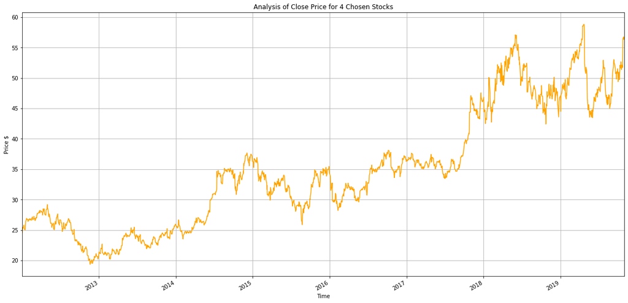

```python
intel_df['Close'].plot(figsize=(20, 10),color='orange')
plt.title("Analysis of Close Price for 4 Chosen Stocks")
plt.grid()
plt.ylabel("Price $")
plt.xlabel("Time")
plt.show()
```

Upon first look at this stock, the stock seems to become somewhat volatile in 2018, which a lot of changes in price over a relative short period of time.

```python
intel_df['Close'].idxmax()
```

```
Timestamp('2019-04-22 00:00:00')
```

We can see that the max price for intel stock reached a high on the 22nd of April 2019. This was followed shortly after by a very sharp decrease in stock price.

After doing a bit of research, I discovered that Intel, on the 26th of April released their earning results for the first quarter of 2019. These showed a cut of $2.5 Billion in Revenue, leading to a massive fall in the price of Intel Stock.

It would be very interesting to see if there are reasons behind all major drops in stock prices across the board for our 4 chosen stocks

In order to smooth out this graph slightly, we can use a moving average in order to show better the trend of the stock price over these 8 years. To do this, I have chosen to use a 50 day average in order to display the information. This was chosen based on the number of entries found in this dataset.

```python
intel_close = intel_df['Close']
intel_mavg = intel_close.rolling(window=50).mean()
```

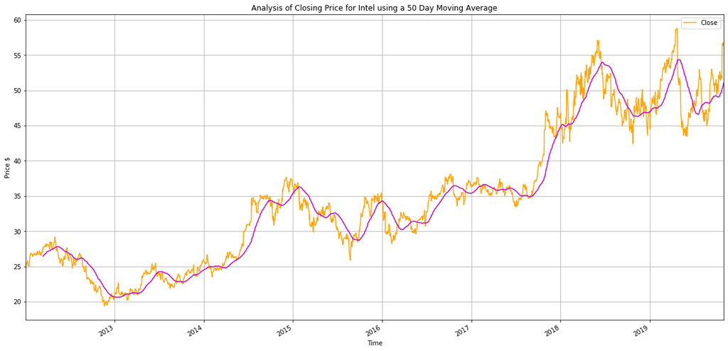

```python
intel_df['Close'].plot(figsize=(20, 10),color='orange')
plt.title("Analysis of Closing Price for Intel using a 50 Day Moving Average")
plt.plot(intel_mavg,color='m')
plt.grid()
plt.ylabel("Price $")
plt.xlabel("Time")
plt.legend()
plt.show()
```

One more way in which we can analyse this intel stock is by plotting the return of the stock from one given day to the next

```python
intel_returns = intel_close / intel_close.shift(1) - 1
```

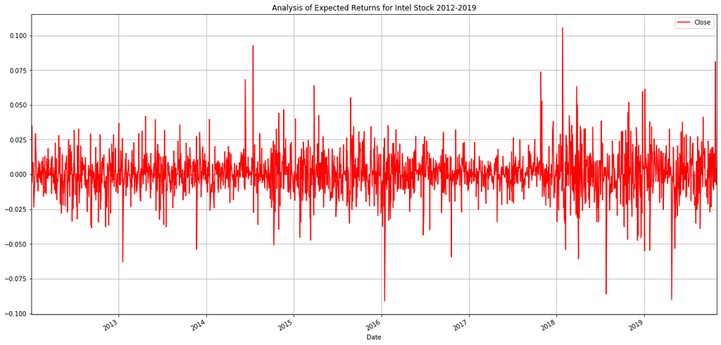

```python
intel_returns.plot(figsize=(20, 10),color='r')
plt.title("Analysis of Expected Returns for Intel Stock 2012-2019")
plt.grid()
plt.legend()
plt.show()
```

The ideal trend for a graph such as this would be for there to be mostly positive spikes in the graph. This however is not the case for this chart. While there is a steady enough number of positive spikes evident in this chart, there are also a lot of cases where the price drops significantly.

For an example of this, we can look at the low spike in 2016, when the stock lost almost 10% of its worth in a day. This is a very dangerous prospect for potential investors as it shows unreliability.

While this is counteracted by spikes such as the one at the beginning of 2018 where the stock rose by 10% in a day, there is still a lot of volatility in the stock history for a potential investor.

One final visualisation of this intel data combines all 4 of the data columns in our dataset. This is done using a candelstick chart and is a very effective visualisation method.

```python
intel_candlestick = go.Figure(data=[go.Candlestick(x=intel_df.index,
                    open=intel_df['Open'],
                    high=intel_df['High'],
                    low=intel_df['Low'],
                    close=intel_df['Close'])])

intel_candlestick.update_layout(
    title="Intel 2012-2018",
    xaxis_title="Price",
    yaxis_title="Time",
)

intel_candlestick.show()
```

[interactive chart not shown]

This candlestick chart provided by pyplot give us a very useful slider which we can use to view the data over a much shorter period of time.

For example, if we look at the month of September 2019, we can see that the closing price is initially higher than the opening for roughly the first two weeks of the month, but the following week we see this reverse.

While over the entire dataset it might be hard to visualise exactly what is happening in this graph, when focusing in on a single year we can see more accurately the trends which materialise in the data when graphing it in forms such as this candlestick graph.

It is interesting to note two major drops in the stock price upon releasing the first quarterly review of the company, a pattern which has appeared in both 2018 and 2019

# Analysis of EA Dataset

[figure not shown]

We can also check this dataset for missing days. We will compare this to the list above to find if there are any other missing days

```python
ea_difference = pd.date_range(start = '2012-01-03', end = '2019-10-31',).difference(ea_df.index)
```

```python
ea_closedlist = []

for i in range(0,len(ea_difference)):
    if(is_business_day(ea_difference[i])):
        ea_closedlist.append(ea_difference[i])
```

```python
if(ea_closedlist == intel_closedlist):
    print("The missing days are identical")
else:
    print("There is a difference in missing days")
```

```
The missing days are identical
```

We will analyze this data in much the same way as we analysed the intel data. We will however skip the intial stock graph and move straight to the graph which contains the moving average aswell as just the close price for the stock. We will again use a 50 day rolling mean.

```python
ea_close = ea_df['Close']
ea_mavg = ea_close.rolling(window=50).mean()
```

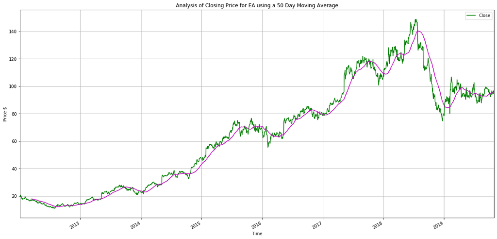

```python
ea_df['Close'].plot(figsize=(20, 10),color='green')
plt.title("Analysis of Closing Price for EA using a 50 Day Moving Average")
plt.plot(ea_mavg,color='m')
plt.grid()
plt.ylabel("Price $")
plt.xlabel("Time")
plt.legend()
plt.show()
```

```python
ea_df['Close'].idxmax()
```

```
Timestamp('2018-07-18 00:00:00')
```

We can see from this graph that the stock price of EA has also increased over time, albeit a lot more sharply than the intel stock. We have a very gradual rise to the max point, which occured on the 18th of July 2018. This was followed by a massive drop in the stock price, falling from over $140 to under $80 in less than 6 months.

The reasons for this are a poor third quarter of 2018, with games such as Battlefield V failing to meet the expectations EA set for it. By pushing back the release date from October to November, which was announced in late July, the game had to compete with a wider variety of AAA titles like Call of Duty: Black Ops 4 and Red Dead Redemption 2.

Despite this however, we still see a video game developer whos stock prices have risen massively over the period, with potential to grow again in the future with more releases.

```python
ea_returns = ea_close / ea_close.shift(1) - 1
```

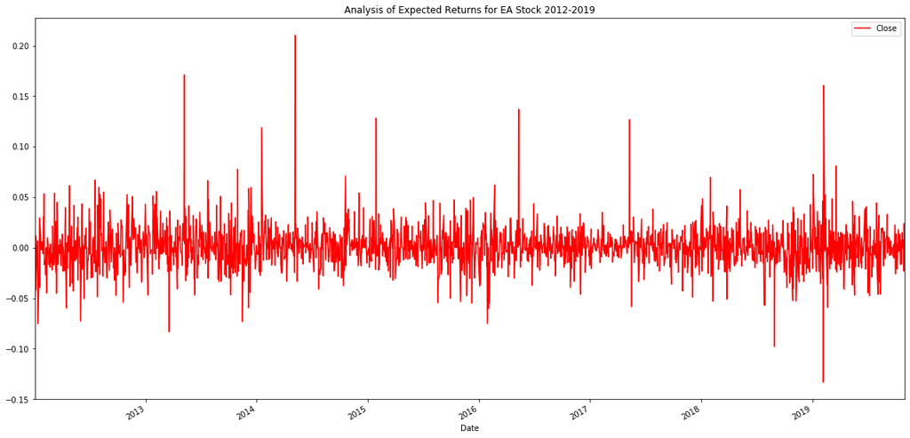

```python
ea_returns.plot(figsize=(20, 10),color='r')
plt.title("Analysis of Expected Returns for EA Stock 2012-2019")
plt.legend()
plt.show()
```

We can see from this chart that there is a big difference in the returns for EA compared to that of Intel. From first glance, it is clear to see that there are not as many larger downwards spikes present in the chart.

We can also see that there are many sharp upwards spikes evident in the data. This means that this there have been many times over the past 8 years where the price of the stock has risen extremely quickly in the space of a day.

As well as this, there is a much higher proportion of upwards spikes in total, especially in the middle proportion of the graph. While in more recent times, the stock has suffered from losses in price, overall we see somewhat of a stable stock, with a lot of continued growth.

```python
ea_candlestick = go.Figure(data=[go.Candlestick(x=ea_df.index,
                    open=ea_df['Open'],
                    high=ea_df['High'],
                    low=ea_df['Low'],
                    close=ea_df['Close'])])

ea_candlestick.update_layout(
    title="EA 2012-2018",
    xaxis_title="Price",
    yaxis_title="Time",
)

ea_candlestick.show()
```

[interactive chart not shown]

In this graph we can see a lot of the points made with the previous two graphs. For example, we can see a lot of green days leading up to the drop which occurs in July 2018. As can be seen throughout the graph, we still have a lot of days in which the closing price is less than the opening price, but these are far outweighed by the amount the price changes on the green days. This leads to an overall increase across the first 5 years.

It is also interesting to note when looking at just the data for 2019 that the prices do not change very much at all. What happens is series of alternating 2-4 day periods where the change is red or green. This leads to overall very little change in the price data over time.

Looking at 2018 individually in a candlestick graph may give us a great insight into the rise and fall of the stock.

```python
ea_year = ea_df["2018"]
```

```python
ea_scandlestick = go.Figure(data=[go.Candlestick(x=ea_year.index,
                    open=ea_year['Open'],
                    high=ea_year['High'],
                    low=ea_year['Low'],
                    close=ea_year['Close'])])

ea_scandlestick.update_layout(
    title="EA 2018",
    xaxis_title="Price",
    yaxis_title="Time",
)


ea_scandlestick.show()
```

[interactive chart not shown]

Overall with this EA stock, we can see that is has increased dramatically since the data began in early 2012, with a very gradual increase in price, but also a rapid loss of price in late 2018. Despite this, as seen from the returns graph, we have a relatively stable stock which hasn't in the past 8 years differed massively in a negative sense apart from the drop in late 2018.

For the future, with the mobile games market increasing very rapidly, I would personally expect the stock price of EA to rise again as it has proven to be a company which has generated a lot of profit in the past when it has produced games which sold successfully.

# Analysis of Microsoft Dataset

We will again quickly run a check to see if there are any missing days

```python
msft_difference = pd.date_range(start = '2012-01-03', end = '2019-10-31',).difference(msft_df.index)
msft_closedlist = []

for i in range(0,len(msft_difference)):
    if(is_business_day(msft_difference[i])):
        msft_closedlist.append(msft_difference[i])

if(msft_closedlist == intel_closedlist):
    print("The missing days are identical")
else:
    print("There is a difference in missing days")
```

```
The missing days are identical
```

For the purpose of analyzing this data, we will also draw the stock data on a simple graph. This time however, we will draw multiple moving average lines in order to show the difference that the moving average will make on the data.

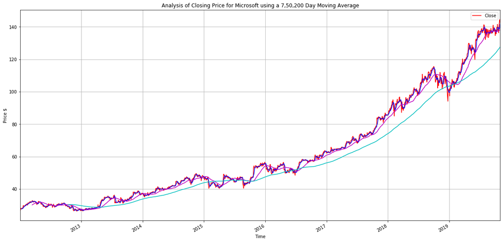

```python
msft_close = msft_df['Close']
msft_mavg_7 = msft_close.rolling(window=7).mean()
msft_mavg_50 = msft_close.rolling(window=50).mean()
msft_mavg_200 = msft_close.rolling(window=200).mean()

msft_df['Close'].plot(figsize=(20, 10),color='red')
plt.title("Analysis of Closing Price for Microsoft using a 7,50,200 Day Moving Average")
plt.grid()
plt.plot(msft_mavg_7,color='b')
plt.plot(msft_mavg_50,color='m')
plt.plot(msft_mavg_200,color='c')
plt.ylabel("Price $")
plt.xlabel("Time")
plt.legend()
plt.show()
```

This is a great visualisation of what the moving average actually shows when used in a graph. It is an excellent method of showing the overall trend of a stock over a time period.

In terms of the data shown by this method, we can see that Microsoft has been a very steady riser over the past 8 years. There is only one very significant drop in price over the entire 8 year period. From this graph, I would expect a very positive heavy return spread.

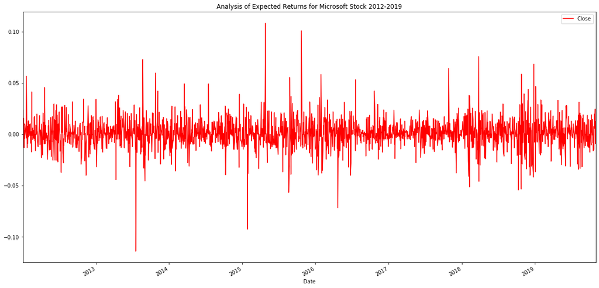

```python
msft_returns = msft_close / msft_close.shift(1) - 1

msft_returns.plot(figsize=(20, 10),color='r')
plt.title("Analysis of Expected Returns for Microsoft Stock 2012-2019")
plt.legend()
plt.show()
```

This is a very interesting graph who's results are slightly surprising. This graph shows a number of points where the share price dropped very significantly (-7+%). What is useful to keep in mind however is that the higher the price of a stock at a given time, the less impact a loss in percentage makes on the actual price lost.

Therefore I feel like analysing a year on its own would be very interesting in this manner. We will choose 2018 and will also draw the mean for reference. It is necessary to note that 2018 is the only year in which there was a major drop, and this may skew our data slightly

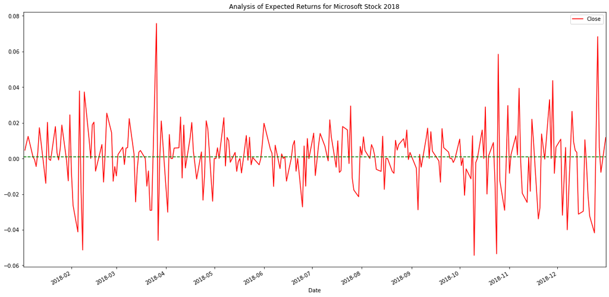

```python
msft_close_2018 = msft_df['Close']
msft_close_2018 = msft_close_2018['2018']

msft_returns = msft_close_2018 / msft_close_2018.shift(1) - 1

msft_returns.plot(figsize=(20, 10),color='r')
plt.axhline(msft_returns.mean(),color='g', linestyle='--')
plt.title("Analysis of Expected Returns for Microsoft Stock 2018")
plt.legend()
plt.show()
```

This zoomed in graph allows us much more insights into the data. As we can see the mean is positive, which is a good sign for potential investors. We also see that there are numerous instances of both positive and negative spikes in this data which were not as obvious in the previous graph.

```python
msft_q4 = msft_df['2018']
msft_q4 = msft_q4[msft_q4.index.quarter==4]

msft_candlestick = go.Figure(data=[go.Candlestick(x=msft_q4.index,
                    open=msft_q4['Open'],
                    high=msft_q4['High'],
                    low=msft_q4['Low'],
                    close=msft_q4['Close'])])

msft_candlestick.update_layout(
    title="Microsoft Quarter 4 2018",
    xaxis_title="Price",
    yaxis_title="Day",
)

msft_candlestick.show()
```

[interactive chart not shown]

This displaying of the data is a lot clearer and more useful than the last method. It shows what days are up from the opening and down from the opening, but also shows how these build from each other day on day. As such it is a much easier to understand method of visualisation.

This seems to have been a trend in the first 3 stocks which I have looked into, with a fall in late 2018 quite significant in all of the stocks. It will be interesting to look into this later on when we compare between stocks

# Analysis of IBM Dataset

The final stock which we will analyze individually is the IBM stock. We will quickly again check for any missing days.

```python
ibm_difference = pd.date_range(start = '2012-01-03', end = '2019-10-31',).difference(ibm_df.index)
ibm_closedlist = []

for i in range(0,len(ibm_difference)):
    if(is_business_day(ibm_difference[i])):
        ibm_closedlist.append(ibm_difference[i])

if(ibm_closedlist == intel_closedlist):
    print("The missing days are identical")
else:
    print("There is a difference in missing days")
```

```
The missing days are identical
```

We will draw the data using a line graph, again using a 50 day moving average

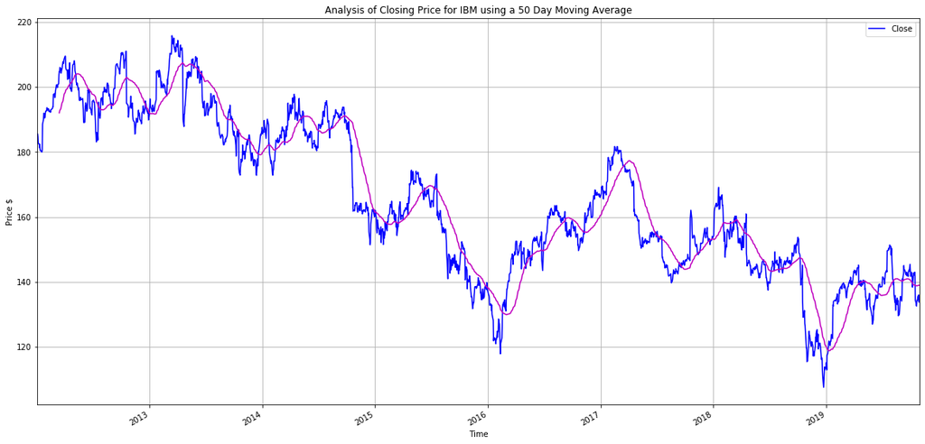

```python
ibm_close = ibm_df['Close']
ibm_mavg = ibm_close.rolling(window=50).mean()

ibm_df['Close'].plot(figsize=(20, 10),color='blue')
plt.title("Analysis of Closing Price for IBM using a 50 Day Moving Average")
plt.grid()
plt.plot(ibm_mavg,color='m')
plt.ylabel("Price $")
plt.xlabel("Time")
plt.legend()
plt.show()
```

After failing revenue goals repeatedly between 2012 and the end of 2015, in 2016 IBM repeatedly met their revenue targets, and as such, the price of the stock grew significantly. There however was a massive drop in price however in 2018, bringing the stock price to a new minimum. This has been a trend all across our stocks, and something we will look into deeply further on in this project.

It will be very interesting to compare this stocks to the other 3 companies as they have very different stock price history.

We can see massive changes in the price over very short periods of time, so both the returns and the candlestick graph will be very interesting to see.

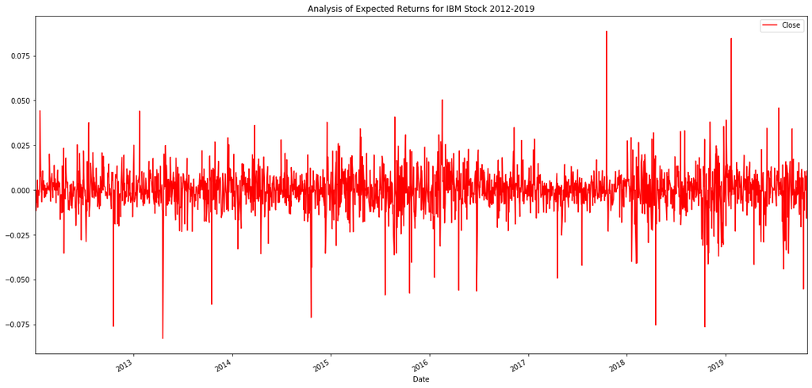

```python
ibm_returns = ibm_close / ibm_close.shift(1) - 1

ibm_returns.plot(figsize=(20, 10),color='r')
plt.title("Analysis of Expected Returns for IBM Stock 2012-2019")
plt.legend()
plt.show()
```

This is a very clear indication of the trend which is also evident in the first graph above. The majority of the spikes are downwards, in line with the downward trending moving average which can be seen above. While the stock price for the IBM stock actual ends up roughly the same as the price for Microsoft stock, at the time our data starts 8 years previous, an IBM stock was almost well over 6 times the price of a Microsoft stock. This goes to show the massive stock value IBM has lost.

This time we will analyse the data on a monthly candlestick graph in order to see a clearer picture. For the purpose of this, we will choose March 2018

```python
ibm_mar = ibm_df["2018-03"]

ibm_candlestick = go.Figure(data=[go.Candlestick(x=ibm_mar.index,
                    open=ibm_mar['Open'],
                    high=ibm_mar['High'],
                    low=ibm_mar['Low'],
                    close=ibm_mar['Close'])])

ibm_candlestick.update_layout(
    title="IBM March 2018",
    xaxis_title="Price",
    yaxis_title="Day",
)

ibm_candlestick.show()
```

[interactive chart not shown]

```python
loss = 100*((ibm_df['Close'].iloc[0]-ibm_df['Close'].iloc[1970])/ibm_df['Close'].iloc[0])
```

```python
print(str(round(loss,1)) + "% lost between the first day and the final day of data")
```

```
27.9% lost between the first day and the final day of data
```

This candlestick graph is very effective in showing us in a clearer sense what is actually happening in the candlestick graphs which i have already created in this project. It shows not only the importance of a change in price for a given day, but also how the days continue and build on from each other.

For this data, we can see mostly see the stock moving up and down every second day, with the occasional two day dip or rise in closing price

# Analysis Between These 4 Companies

Firstly, I would like to contrast the 'High' prices between the 4 of these companies. This will give us an insight into the general trend of the companies stocks over the past 8 years. We will do this by creating a dataframe containing the date, and the high columns for all 4 of the companies. As we may want to do this for all 4 columns, we will make a function

```python
ibm_high = ibm_df['High']
intel_high = intel_df['High']
ea_high = ea_df['High']
microsoft_high = msft_df['High']

high_price_df = { 'IBM' : ibm_high, 'Intel' : intel_high, 'EA': ea_high, 'Microsoft' : microsoft_high}
high_price_df = pd.DataFrame(high_price_df)
```

##### This function allows us to concatenate certain chosen columns

```python
def concat_columns(str):
    ibm = ibm_df[str]
    intel = intel_df[str]
    ea = ea_df[str]
    microsoft = msft_df[str]

    result = { 'IBM' : ibm, 'Intel' : intel, 'EA': ea, 'Microsoft' : microsoft}
    result = pd.DataFrame(result)

    return result
```

```python
high_price_df = concat_columns("High")
```

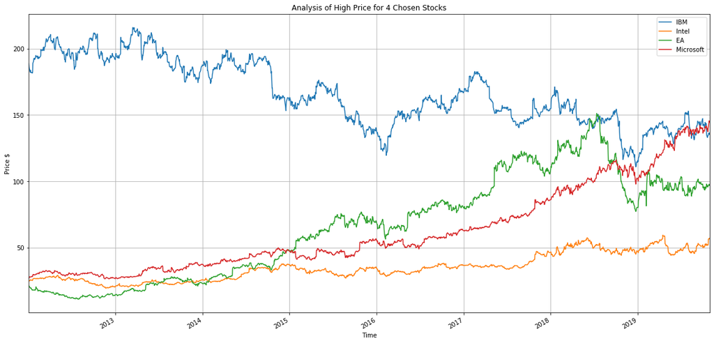

```python
high_price_df.plot(figsize=(20, 10))
plt.title("Analysis of High Price for 4 Chosen Stocks")
plt.grid()
plt.ylabel("Price $")
plt.xlabel("Time")
plt.show()
```

While this is an interesting way to view the stock prices, the most common and effective way to analyze these based on columns would be through the closing price. We will again use our function from above.

```python
close_price_df = concat_columns("Close")
```

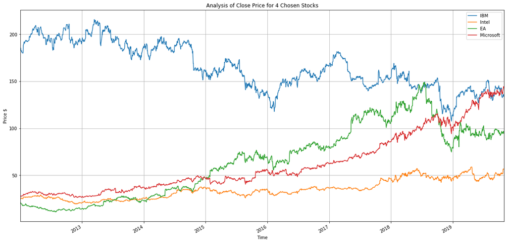

```python
close_price_df.plot(figsize=(20, 10))
plt.title("Analysis of Close Price for 4 Chosen Stocks")
plt.grid()
plt.ylabel("Price $")
plt.xlabel("Time")
plt.show()
```

This is a fair way to analyze the data, and as such we can compare the different trends while using the same axis. As we have already mentioned above, IBM started 2012 much higher than even the other 3 companies combined. Despite this, the other three companies, especially Microsoft and EA have closed the gap massively over the past 8 years, with Microsoft even passing out IBM right at the end of the period.

Intel has climbed steadily over the past 8 years, and with 80% of the worlds PC's using intel processors, it is no surprise that they have grown alongside Microsoft and EA, while IBM has been somewhat "left behind" as technology has developed in recent years.

It will be very interesting to see what correlation if any these companies have with each other, especially Microsoft and Intel. With such a high market share in PC's for each of these companies, there will be no doubt that the continuing growth of computers in the world will have had a positive effect on the stock prices.

Another interesting graph to compute would be the moving average for these 4 stocks. This should result in a smoother chart, showing the general trend of the stocks

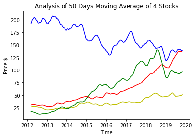

```python
plt.title("Analysis of 50 Days Moving Average of 4 Stocks")
plt.plot(intel_mavg,color='y')
plt.plot(msft_mavg_50,color='r')
plt.plot(ea_mavg,color='g')
plt.plot(ibm_mavg,color='b')
plt.ylabel("Price $")
plt.xlabel("Time")
plt.show()
```

The results are very similar, with slightly rounded and smoothed lines

# A Look into October 2018

As seen earlier on in this project, we noticed that there seemed to be a huge decline for a lot of these stocks in late 2018. We will now focus on that year and look into possible reasons for this small 'crash'. The most relevant way to do this would be to take the percentage change for all 4 of these companies and graph them

```python
close_price_2018 = close_price_df['2018']
```

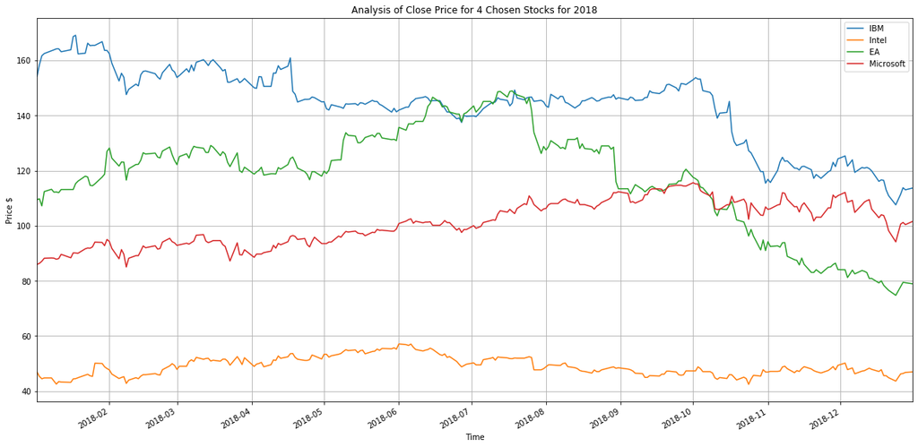

```python
close_price_2018.plot(figsize=(20, 10))
plt.title("Analysis of Close Price for 4 Chosen Stocks for 2018")
plt.grid()
plt.ylabel("Price $")
plt.xlabel("Time")
plt.show()
```

Even despite this drop across the market, technology stocks were the biggest hit. While not included in this data, Amazon and Netflix dropped 20.2 and 19.3 percent respetively. This provided us a reason for this drop, which might be easier to notice when showing the percent change for each day in October.

```python
comparison = close_price_df.pct_change()
```

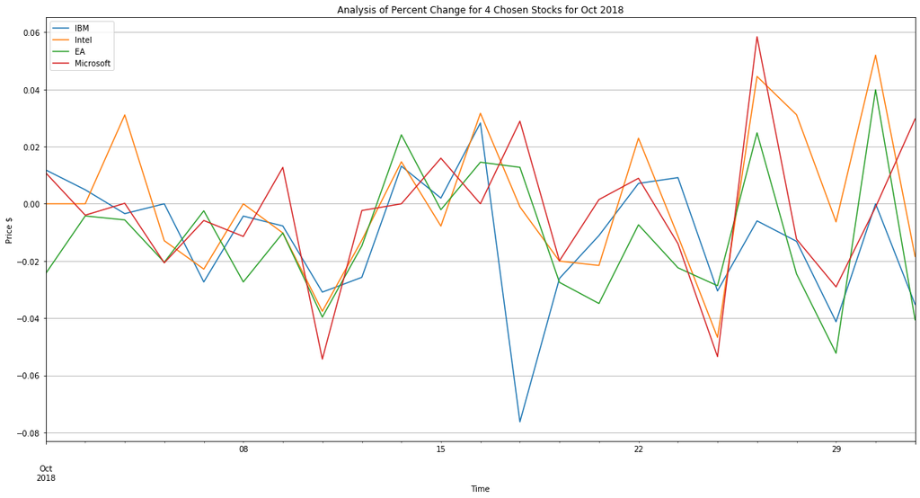

```python
comparison_2018 = comparison['2018-10']
comparison_2018.plot(figsize=(20, 10))
plt.title("Analysis of Percent Change for 4 Chosen Stocks for Oct 2018")
plt.grid()
plt.ylabel("Price $")
plt.xlabel("Time")
plt.show()
```

This even more succesfully illustrate the point which I alluded to above. As we can see, many of the stocks plummeted on the same day as the entire market took a hit

# Correlation using Closing Price

```python
comparison_close = close_price_df.corr()
```

```python
comparison_close
```

|  | IBM | Intel | EA | Microsoft |
| --- | --- | --- | --- | --- |
| IBM | 1.000000 | -0.735701 | -0.785568 | -0.740868 |
| Intel | -0.735701 | 1.000000 | 0.853459 | 0.927548 |
| EA | -0.785568 | 0.853459 | 1.000000 | 0.805903 |
| Microsoft | -0.740868 | 0.927548 | 0.805903 | 1.000000 |

```
array([[<matplotlib.axes._subplots.AxesSubplot object at 0x000001C52BBCAF98>,
      dtype=object)
```

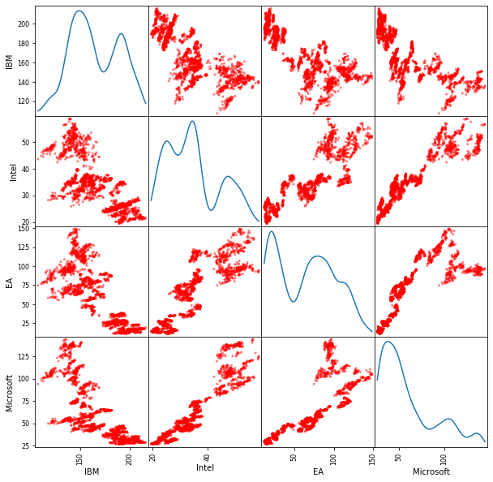

```python
scatter_matrix(close_price_df,figsize=(10,10),color='r',diagonal='kde')
```

We can see even from first glance here that a lot of our correlations are very strong. The reasoning behind this is that we have chosen 3 stocks which have steadily increased for the majority of this 8 year cycle. This however is contrasted by the IBM stock, which has fallen quite significantly since 2012. We can see this visualised in the graph above. Another heatmap may show this even better

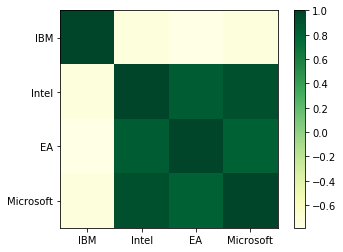

```python
plt.imshow(comparison_close, cmap='YlGn', interpolation='none')
plt.colorbar()
plt.xticks(range(len(comparison_close)), comparison_close.columns)
plt.yticks(range(len(comparison_close)), comparison_close.columns);
```

This is a given due to the fact that we have chosen stocks in which 3 of them rise relatively steadily. We will have to now create a correlation based on a more accurate metric in order to get any meaningful results

# Correlation using Percentage Change

We can now analyze the correlation of these stocks using the percentage change. We will make a table from our closing data in order to do this

```python
correlation = comparison.corr()
```

```python
correlation
```

|  | IBM | Intel | EA | Microsoft |
| --- | --- | --- | --- | --- |
| IBM | 1.000000 | 0.398911 | 0.205527 | 0.384362 |
| Intel | 0.398911 | 1.000000 | 0.268396 | 0.489849 |
| EA | 0.205527 | 0.268396 | 1.000000 | 0.303594 |
| Microsoft | 0.384362 | 0.489849 | 0.303594 | 1.000000 |

Firstly, we will graph the correlation in a scatter matrix. This should give us a general overview of which combinations of our data correlate to each other

```
array([[<matplotlib.axes._subplots.AxesSubplot object at 0x000001C52A9F70B8>,
      dtype=object)
```

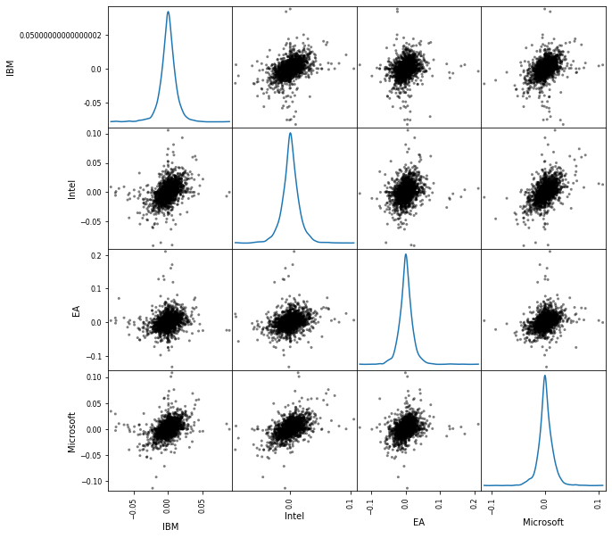

```python
scatter_matrix(comparison,figsize=(10,10),color='black',diagonal='kde')
```

An easier way in which we can display this data is by using a heatmap. The darker the colour of red, the more correlated the columns are to one another

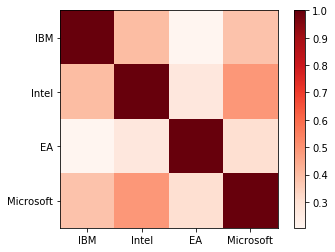

```python
plt.imshow(correlation, cmap='Reds', interpolation='none')
plt.colorbar()
plt.xticks(range(len(correlation)), correlation.columns)
plt.yticks(range(len(correlation)), correlation.columns);
```

From both this and the table above, we can see that there are a lot of correlations evident in this dataset, as expected. Unsurprisingly, Microsoft and Intel have a seemingly strong correlation. We will now look into this with a bit more detail.

Firstly, we can use both of these moving averages to visualise the trends evident in the datasets

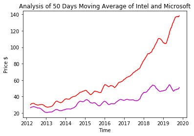

```python
plt.title("Analysis of 50 Days Moving Average of Intel and Microsoft")
plt.plot(intel_mavg,color='m')
plt.plot(msft_mavg_50,color='r')
plt.ylabel("Price $")
plt.xlabel("Time")
plt.show()
```

While we can see that both of these have continual upward trending 50 day averages, it is evident that Microsoft has grown almost exponentially more, especially from mid 2016 onwards.

Despite this, a correlation coefficient of 0.49 in the percentage change in both of these sets shows a moderate positive relationship between the two stocks. This should come as no surprise, with 80% of PC's running intel processors, and with 70% of PC's running windows, no correlation would have been a huge surprise.

We can show these on a scatter plot in order to look further into this data.

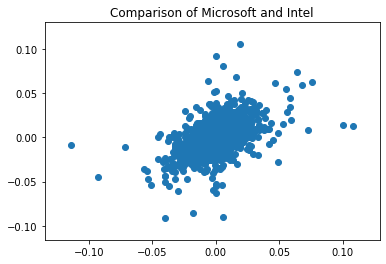

```python
plt.title("Comparison of Microsoft and Intel")
plt.scatter(comparison['Microsoft'],comparison['Intel'])
```

We can see a clear correlation between the percentage change in the two companies stocks. It would be interesting to draw a regression line on this scatter plot in order to find a possible dependent and independent variable. I would imagine that as demand for Windows increases, the stock price of Intel would rise, as 80% of PCs use intel processors.

```python
simp_comparison = comparison[['Microsoft','Intel']]
```

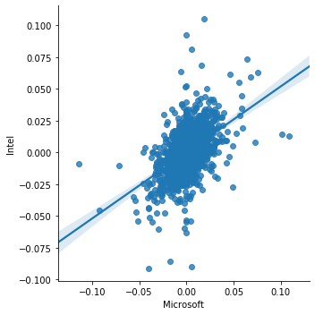

```python
seab.lmplot(x='Microsoft',y='Intel',data=simp_comparison,fit_reg=True)
```

We can now try to find an equation to calculate the intel daily change given the microsoft daily change for future values. For this i will be using statsmodel linear regression function

```python
model = smf.ols('Intel ~ Microsoft',data=simp_comparison)
model = model.fit()
```

```python
model.params
```

```
Intercept    0.000043
Microsoft    0.520737
dtype: float64
```

**Thus the equation for our model will be Intel = 0.000043 + 0.520737*Microsoft**

Whether this equation would actually work for real life data is another question, however from viewing the graph it looks to be that the intercept for this line is in line with this equation. Of course, if it was as simple as this to predict stock prices it would not be a difficult pursuit at all, and as such there are many factors which may prevent a model such as this from working

# Further Correlations

This however is not the only correlation found in the dataset. What surprises me is the correlation found between IBM and both Microsoft and Intel. While they are both technology companies, the trend of the IBM stock was extremely different to both Microsoft and Intel. We should take a quick look at this correlation

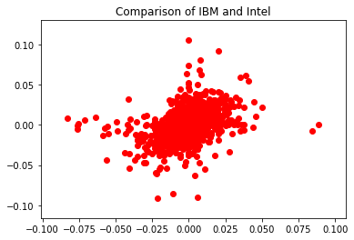

```python
plt.scatter(comparison['IBM'],comparison['Intel'],color="red")
plt.title("Comparison of IBM and Intel")
```

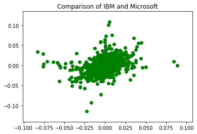

```python
plt.scatter(comparison['IBM'],comparison['Microsoft'],color="green")
plt.title("Comparison of IBM and Microsoft")
```

These graphs are very simple, but show from even a simple glance that there is a correlation between the three of these companies. While the correlation coefficients are not as high as previously, at 0.398911 and 0.384362 respectively, these are still low-moderate correlations which I found to be very surprising.

From previously using the closing price data correlation, we have now found some meaningful data in which to analyze. One of the main points which is quite clear to see from the heatmap shown above, EA is the company here which has the least correlation with any of the other 3.

This could be accounted to many reasons, but is more than likely due to the fact that EA is a company which produces games, which is not what a lot of people use their PC's or even Windows for. This therefore does not come as much of a surprise that EA has the least relationship with the other stocks.

# Final Conclusions

We have seen through the individual analysis found above how the 4 chosen companies, IBM, Intel, EA and Microsoft have developed over the past 8 years. In the case of Intel, we have a company who has steadily rose over the past eight years, and has just about doubled in size.

We then have Microsoft, who have increased their price by a scale of 5, with only 1 drop a long the way. Similarly up until mid 2018, we had EA doing the same, before a very sharp drop in price brought them back towards 2017, albeit still much ahead of 2012.

In contrast to this, we have IBM, who started off with more share price then the other 3 companies combined. Since then, IBM share price has plummeted, losing almost 30% of their stock price in the space of 8 years.

What was surprising however was the correlations between both Intel and Microsoft with IBM. Considering IBM had performed so differently to the others in the period, we expected very little correlation, but in fact were met with a weak-moderate correlation.

With only very little correlations with the other 3 companies, EA would have to be considered the odd one out in this analysis. This makes sense, as despite EA produced games requiring Windows and CPUs to run, the majority of modern PC users are not using their systems for Gaming.

Overall, I attempted to analyse these stocks over varying time periods, both individually and together, and I feel like I have found some sort of meaningful results which tell a lot about each one of these stocks and their 8 year histories